# Data Driven Modeling

# MACHINE LEARNING AND DATA STREAMS

[Vahid Moosavi](https://vahidmoosavi.com/)

24 October 2017

```python
import warnings
warnings.filterwarnings("ignore")
import pandas as pd
import numpy as np
from matplotlib import pyplot as plt
pd.__version__
import sys
%matplotlib inline
```

# A bit of background in scientific modeling and scientific methods

[figure not shown]

### Key terms:

- Holistic view
- Interdisciplinary
- multidisciplinary
- transdisciplinary

[figure not shown]

# My research questions as a systems engineer

# Why do these concepts come and go?

# How to behave against these approaches If you are an architect or urban designer and not a systems of computer scientist?

# How to find the mega trends and how to categorize the abstract similarities among these approaches?

[figure not shown]

# systemic views (disciplines within systems theory)

[figure not shown]

# What are the fundamental assumptions in classical scientific (rational) modeling?

[figure not shown]

# However, this approach reach to a limit in many complex pheonemena like cities

### Examples:

#### patterns of movement of people in street comparing to patterns of molecules in an ideal gas

#### Our natural languages

# An alternative approach: Can we do not start from this idealization?

# Can we encapsulate the complexity without explicit representations?

### The origins of data driven modeling

[figure not shown]

# And now we are within this world of data

[figure not shown]

```python
from IPython.display import YouTubeVideo
YouTubeVideo('D6XTyLbO13w',width=1000, height=600)
```

[video not shown]

# So now the modeling process has been inverted

## The primary role of Data in Data Driven Modeling

[figure not shown]

# But data alone is not going anywhere

# We need new mathematical and computational thinking

# And this is the role of Machine Learning in my opinion

## Least Square method (1801 Gauss)

[figure not shown]

And the whole field of machine learning is about how to find a good f.

Note that the final model is not necessarily representational

# Looking at these concepts over time

### Using Google N-Gram Viewer

```python
import datetime
import pandas as pd
# import pandas.io.data
import numpy as np
from matplotlib import pyplot as plt
import sys
import getngrams as ng# from pandas import Series, DataFrame
# import xkcd as fun
%matplotlib inline
# kw = ['Mainframe Computer','Personal Computer','Sensor','Computer Network','Internet', 'Data Mining','Pervasive Computing',
#       'Smart Phone','Communication Technology','Simulation','Micro Simulation','Web 2.0'
#       ]

kw = ['Machine Learning','Differential Equations']
A = pd.DataFrame()
for i in range(len(kw)):
    try:
        tmp = ng.runQuery('-nosave -noprint -startYear=1940 -smoothing=3 -endYear=2008 -caseInsensitive '+kw[i])
#         A['year']=tmp.year.values[:]
        weights = tmp.values[:,1:]
        mx  = np.max(weights,axis=0)
        mn  = np.min(weights,axis=0)
        R = mx-mn
        weights = (weights-mn)/R
        tmp.ix[:,1:]=weights
        A[kw[i]]=tmp.values[:,1]

    except:
        print kw[i], 'not enough data'
```

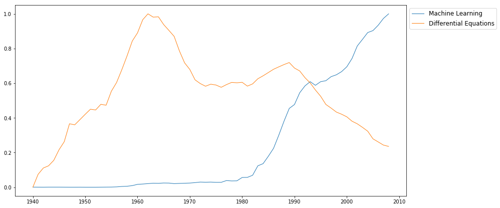

```python
fig = plt.figure()
for i in range(len(kw)):
    try:
        plt.plot(tmp.year,A[kw[i]],linewidth=1,label=kw[i])
        xticks = np.arange(tmp.year[0],2011,10).astype(int)
        plt.xticks(xticks)
#         plt.yticks([])
    except:
        print kw[i], 'not enough data'

#
plt.legend(loc='best',bbox_to_anchor = (1.0, 1.0),fontsize = 'large')
fig.set_size_inches(14,7)
```

# So my research agenda over the last 6 years have been on what is machine learning and what is it good for?

## My thesis :

Vahid Moosavi, Pre-Specific Modeling, Computational Machines in Coexistence with Urban Data Streams. Diss., Eidgenössische Technische Hochschule ETH Zürich, Nr. 22683, 2015. [link](http://e-collection.library.ethz.ch/eserv/eth:48219/eth-48219-02.pdf)

## My seminar series on machine learning and data

- https://github.com/sevamoo/data_driven_modeling_2016
- https://github.com/sevamoo/data_driven_modeling_2017

# But machine Learning itself is evolving quickly

[figure not shown]

# Going back to story of General Systems Theory

## With this new approach we can talk science differently!

[figure not shown]

# A Major shift and a big question

But if classically expertise means that you know the rules, equations,... in a certain discipline, now we can encapsulate any type of expertise!

# How should we orient ourselves in the world of data?

[figure not shown]

# And the Big Data is everywhere! You just need to learn to find it

## Web scraping

## APIs

## Social media

## ...

# Examples related to Cities

[figure not shown]

https://sevamoo.github.io/cityastext/

[figure not shown]

Paper: https://arxiv.org/pdf/1709.02939.pdf

# Next steps

## Can we find alternate patterns of developments for a specific plot of land?

## american community survey

[figure not shown]

http://www.keylead.ch/

# Thanks!